ACDH-CH Digital Prosopography Summer School 2020 | [website](https://acdh-oeaw.gitlab.io/summerschool2020/)

# Analysis III: Statistics, Plotting, Unsupervised ML

2020-07-09, Vienna / Zoom

Sabine Laszakovits | Data Analyst | ACDH-CH | ÖAW | [web](https://www.oeaw.ac.at/acdh/team/current-team/sabine-laszakovits/) | email

## What we'll do

- Basic statistics
  - Exploratory data analysis (EDA)
  - Characteristic numbers
  - Variables
  - Plotting in Python
- Find clusters in the data
  - K-Means algorithm

## The dataset

https://en.wikipedia.org/wiki/Iris_flower_data_set

We have a list of 150 flowers from 3 species of irises with measurements of their leaves.

For now, we want to see what we can observe about these measurements.

Ultimately, we will want to figure out from the measurements, which species each flower belongs to.

Iris setosa

Iris versicolor

Iris virginica

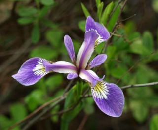

[figure not shown]

source: https://alchetron.com/Iris-setosa

source: https://commons.wikimedia.org/wiki/File:Iris_versicolor_3.jpg

source: https://commons.wikimedia.org/wiki/File:Iris_virginica.jpg

```python
import pandas

data_complete = pandas.read_csv('iris.csv')

data = data_complete.drop(columns=['species']) # that would be cheating
```

```python
data
```

|  | sepal_length | sepal_width | petal_length | petal_width |
| --- | --- | --- | --- | --- |
| 0 | 5.1 | 3.5 | 1.4 | 0.2 |
| 1 | 4.9 | 3.0 | 1.4 | 0.2 |
| 2 | 4.7 | 3.2 | 1.3 | 0.2 |
| 3 | 4.6 | 3.1 | 1.5 | 0.2 |
| 4 | 5.0 | 3.6 | 1.4 | 0.2 |
| ... | ... | ... | ... | ... |
| 145 | 6.7 | 3.0 | 5.2 | 2.3 |
| 146 | 6.3 | 2.5 | 5.0 | 1.9 |
| 147 | 6.5 | 3.0 | 5.2 | 2.0 |
| 148 | 6.2 | 3.4 | 5.4 | 2.3 |
| 149 | 5.9 | 3.0 | 5.1 | 1.8 |

150 rows × 4 columns

What is a "petal" [ˈpɛtəl] and what is a "sepal" [ˈsɛpəl]?

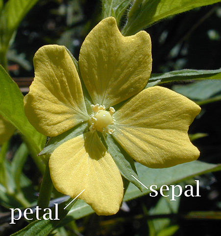

Source: https://commons.wikimedia.org/wiki/File:Petal-sepal.jpg

## Exploratory data analysis

- How many variables are there?
- What is the range of each variable?
- What is the distribution of each variable?
- Are the variables independent or dependent?

### How many variables are there?

```python
data.head()
```

|  | sepal_length | sepal_width | petal_length | petal_width |
| --- | --- | --- | --- | --- |
| 0 | 5.1 | 3.5 | 1.4 | 0.2 |
| 1 | 4.9 | 3.0 | 1.4 | 0.2 |
| 2 | 4.7 | 3.2 | 1.3 | 0.2 |
| 3 | 4.6 | 3.1 | 1.5 | 0.2 |
| 4 | 5.0 | 3.6 | 1.4 | 0.2 |

### What is the range of each variable?

```python
data.describe()
```

|  | sepal_length | sepal_width | petal_length | petal_width |
| --- | --- | --- | --- | --- |
| count | 150.000000 | 150.000000 | 150.000000 | 150.000000 |
| mean | 5.843333 | 3.054000 | 3.758667 | 1.198667 |
| std | 0.828066 | 0.433594 | 1.764420 | 0.763161 |
| min | 4.300000 | 2.000000 | 1.000000 | 0.100000 |
| 25% | 5.100000 | 2.800000 | 1.600000 | 0.300000 |
| 50% | 5.800000 | 3.000000 | 4.350000 | 1.300000 |
| 75% | 6.400000 | 3.300000 | 5.100000 | 1.800000 |
| max | 7.900000 | 4.400000 | 6.900000 | 2.500000 |

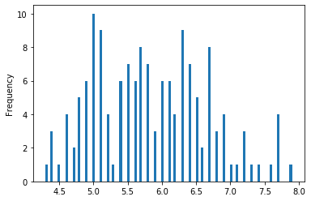

```python
data['sepal_length'].plot.hist(bins=100)
```

#### Minimum, maximum

The smallest and largest value in the set.

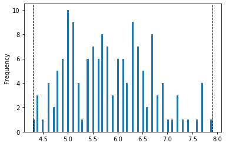

```python
min = data['sepal_length'].min()
max = data['sepal_length'].max()

data['sepal_length'].plot.hist(bins=100)

import matplotlib.pyplot

matplotlib.pyplot.axvline(min, color='k', linestyle='dashed', linewidth=1)
matplotlib.pyplot.axvline(max, color='k', linestyle='dashed', linewidth=1)
```

### What is the distribution of each variable?

- Mean
- Quantiles
- Standard deviation

#### Mean

The arithmetic mean, also known as average.

$\bar{x} = \frac{x_1+x_2+\ldots+x_n}{n} = \frac{\sum_{i=1}^{n}x_i}{n}$

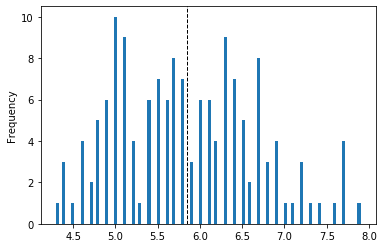

```python
data['sepal_length'].plot.hist(bins=100)

matplotlib.pyplot.axvline(data['sepal_length'].mean(), color='k', linestyle='dashed', linewidth=1)
```

#### Standard deviation (SD, std)

Measures the dispersion of a dataset relative to its mean.

$\sigma = \sqrt{\frac{\sum_{i=1}^n \left(x_i - \bar{x}\right)^2}{n}}$

[Why square?](https://www.mathsisfun.com/data/standard-deviation.html#WhySquare)

The SD is also used to express the confidence in statistical conclusions and to calculate the margin of error.

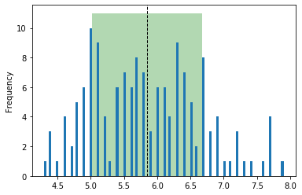

```python
data['sepal_length'].plot.hist(bins=100)

mean = data['sepal_length'].mean()
std = data['sepal_length'].std()

matplotlib.pyplot.axvline(mean, color='k', linestyle='dashed', linewidth=1)

matplotlib.pyplot.fill_between([mean-std, mean+std], 0, 11, facecolor='green', alpha=0.3)
```

##### The effect of the standard deviation

The 2 distributions have the same mean but different standard deviations.

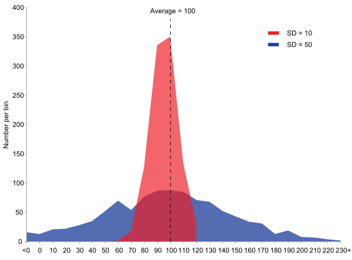

Source: https://commons.wikimedia.org/wiki/File:Comparison_standard_deviations.svg

#### Quantiles

Sort the sample ascending. Partition the sample into $q$ groups with an equal number of datapoints in each group.

Groups have equal probabilities.

Some common quantiles:

- quartile = partition into 4 groups = 4-quantile
- percentile = partition into 100 groups = 100-quantile
- median = 2-quantile

##### Example

25th percentile = the value of the datapoint that is ranked at position $\frac{25}{100}n$

= 1st quartile

```python
# pandas's calculation
q25 = data['sepal_length'].quantile(0.25)
print(f"Calculated value = {q25}")
```

```
Calculated value = 5.1
```

```python
sorted_values = list(data['sepal_length'].sort_values())
q25_index = int(len(sorted_values)*0.25)
q25_value = sorted_values[q25_index]
print(f"Value at index {q25_index} = {q25_value}")
```

```
Value at index 37 = 5.1
```

##### Partitions span across different intervals

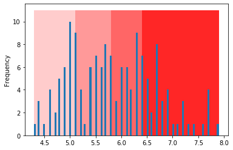

```python
q50 = data['sepal_length'].quantile(0.50)
q75 = data['sepal_length'].quantile(0.75)

data['sepal_length'].plot.hist(bins=100)

matplotlib.pyplot.fill_between([min, q25], 0, 11, facecolor='red', alpha=0.2)
matplotlib.pyplot.fill_between([q25, q50], 0, 11, facecolor='red', alpha=0.4)
matplotlib.pyplot.fill_between([q50, q75], 0, 11, facecolor='red', alpha=0.6)
matplotlib.pyplot.fill_between([q75, max], 0, 11, facecolor='red', alpha=0.85)
```

### Dependencies

We have 4 variables:

- sepal_length
- sepal_width
- petal_length
- petal_width

Are there dependencies between these variables?

Example:

- If sepal_length is a large value, sepal_width is also a large value.
- petal_width is always about twice as large as sepal_width.

#### Dependency between sepal length & sepal width

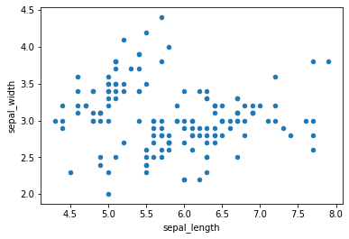

```python
data.plot.scatter(x='sepal_length', y='sepal_width')
```

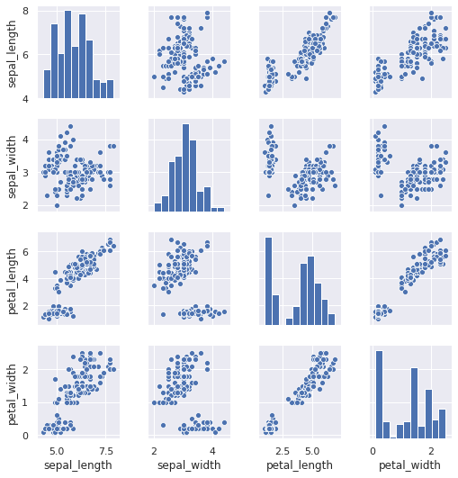

```python
import seaborn
seaborn.set()
seaborn.pairplot(data, height=1.9)
```

It looks like:

- There are dependencies between the 4 variables.
- The dependencies cannot be expressed between pairs of variables.
- We suspect that our sample of flowers consists of multiple clusters. Each cluster refers to a different species of flower.
- The dependencies are best described within each cluster.

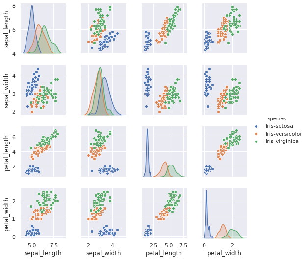

```python
seaborn.pairplot(data_complete, hue="species", height=1.9)
```

## Clustering

We apply a machine learning technique to find the clusters of datapoints.

### Machine Learning

ML = An algorithm looks at data and draws generalizations from it

**Supervised ML** = The algorithm gets a bunch of correctly labeled examples and learns the connection data <=> label.

**Unsupervised ML** = The algorithm gets unlabeled data and finds structure within the data.

### Model

Algorithm + learned generalizations = **model**

We apply a model to new data, where it makes **predictions** by assigning a label.

### K-means algorithm

This is an algorithm that finds $k$ clusters in the given dataset. (You need to specify $k$.)

#### How it works:

1. **Initialize**: Declare at random $k$ datapoints in the dataset. These are the "centers".
2. **Assign**: Assign each datapoint to its closest "center". Now you have temporary clusters.
3. **Update**: For each cluster, calculate the mean. Shift the cluster's center to this mean value.
4. **Iterate**: Keep doing the Assignment step and the Update step until the center points don't move anymore ("converge"). If you've done this for a while and they still don't converge, start over with different random initial centers.

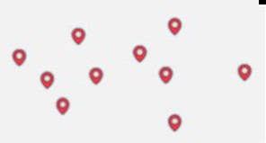

Source: https://www.simplilearn.com/tutorials/machine-learning-tutorial/k-means-clustering-algorithm

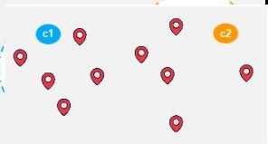

Source: https://www.simplilearn.com/tutorials/machine-learning-tutorial/k-means-clustering-algorithm

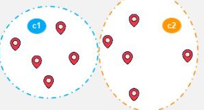

Source: https://www.simplilearn.com/tutorials/machine-learning-tutorial/k-means-clustering-algorithm

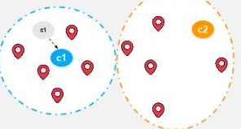

Source: https://www.simplilearn.com/tutorials/machine-learning-tutorial/k-means-clustering-algorithm

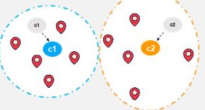

Source: https://www.simplilearn.com/tutorials/machine-learning-tutorial/k-means-clustering-algorithm

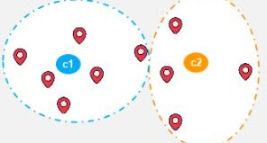

Source: https://www.simplilearn.com/tutorials/machine-learning-tutorial/k-means-clustering-algorithm

#### Points of variation:

- the value $k$
- the randomness of the initialization
- the definition of "closest"
- the definition of "mean"
- the number of iterations you wait for convergence

#### Running the algorithm

Library: https://scikit-learn.org/

```python
from sklearn.cluster import KMeans

km = KMeans(n_clusters=3, n_init=1, random_state=245234) # declare k
km = km.fit(data) # run the algorith on the data
```

```python
km.labels_
```

```
array([1, 1, 1, 1, 1, 1, 1, 1, 1, 1, 1, 1, 1, 1, 1, 1, 1, 1, 1, 1, 1, 1,
       1, 1, 1, 1, 1, 1, 1, 1, 1, 1, 1, 1, 1, 1, 1, 1, 1, 1, 1, 1, 1, 1,
       1, 1, 1, 1, 1, 1, 0, 2, 0, 2, 2, 2, 2, 2, 2, 2, 2, 2, 2, 2, 2, 2,
       2, 2, 2, 2, 2, 2, 2, 2, 2, 2, 2, 0, 2, 2, 2, 2, 2, 2, 2, 2, 2, 2,
       2, 2, 2, 2, 2, 2, 2, 2, 2, 2, 2, 2, 0, 2, 0, 0, 0, 0, 2, 0, 0, 0,
       0, 0, 0, 2, 2, 0, 0, 0, 0, 2, 0, 2, 0, 2, 0, 0, 2, 2, 0, 0, 0, 0,
       0, 2, 0, 0, 0, 0, 2, 0, 0, 0, 2, 0, 0, 0, 2, 0, 0, 2], dtype=int32)
```

```python
km.cluster_centers_
```

```
array([[6.85384615, 3.07692308, 5.71538462, 2.05384615],
       [5.006     , 3.418     , 1.464     , 0.244     ],
       [5.88360656, 2.74098361, 4.38852459, 1.43442623]])
```

#### Evaluate the result

```python
evaluation = {
    'Iris-setosa':     {'0': 0, '1': 0, '2': 0},
    'Iris-versicolor': {'0': 0, '1': 0, '2': 0},
    'Iris-virginica':  {'0': 0, '1': 0, '2': 0}
}

for i in range(len(data_complete)):
    evaluation[data_complete['species'][i]][str(km.labels_[i])] += 1
```

```python
evaluation
```

```
{'Iris-setosa': {'0': 0, '1': 50, '2': 0},
 'Iris-versicolor': {'0': 3, '1': 0, '2': 47},
 'Iris-virginica': {'0': 36, '1': 0, '2': 14}}
```

#### Run the algorithm again

Let's see whether we get a different result with different random initial values.

```python
km2 = KMeans(n_clusters=3, n_init=1, random_state=123657651)
km2 = km2.fit(data)
```

```python
evaluation2 = {
    'Iris-setosa':     {'0': 0, '1': 0, '2': 0},
    'Iris-versicolor': {'0': 0, '1': 0, '2': 0},
    'Iris-virginica':  {'0': 0, '1': 0, '2': 0}
}

for i in range(150):
    evaluation2[data_complete['species'][i]][str(km2.labels_[i])] += 1
```

```python
evaluation, evaluation2
```

```
({'Iris-setosa': {'0': 0, '1': 50, '2': 0},
  'Iris-versicolor': {'0': 3, '1': 0, '2': 47},
  'Iris-virginica': {'0': 36, '1': 0, '2': 14}},
 {'Iris-setosa': {'0': 50, '1': 0, '2': 0},
  'Iris-versicolor': {'0': 0, '1': 48, '2': 2},
  'Iris-virginica': {'0': 0, '1': 14, '2': 36}})
```

```python
km.cluster_centers_, km2.cluster_centers_
```

```
(array([[6.85384615, 3.07692308, 5.71538462, 2.05384615],
        [5.006     , 3.418     , 1.464     , 0.244     ],
        [5.88360656, 2.74098361, 4.38852459, 1.43442623]]),
 array([[5.006     , 3.418     , 1.464     , 0.244     ],
        [5.9016129 , 2.7483871 , 4.39354839, 1.43387097],
        [6.85      , 3.07368421, 5.74210526, 2.07105263]]))
```

```python
km.n_iter_, km2.n_iter_
```

```
(7, 4)
```

#### Plotting the centers

```python
col_names = [ d for d in data ]
col_idx_name = [ (i, col_names[i]) for i in range(len(col_names)) ]
centers = [ { v: c[i] for (i,v) in col_idx_name } for c in km.cluster_centers_ ]
```

```python
centers
```

```
[{'sepal_length': 6.853846153846154,
  'sepal_width': 3.076923076923077,
  'petal_length': 5.7153846153846155,
  'petal_width': 2.053846153846154},
 {'sepal_length': 5.006,
  'sepal_width': 3.418,
  'petal_length': 1.4639999999999995,
  'petal_width': 0.24400000000000022},
 {'sepal_length': 5.883606557377049,
  'sepal_width': 2.740983606557377,
  'petal_length': 4.388524590163934,
  'petal_width': 1.4344262295081966}]
```

#### Predicted species

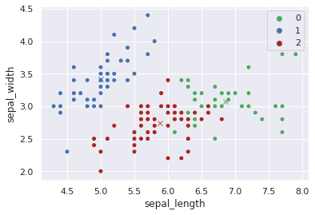

```python
c = {0: 'g', 1: 'b', 2: 'brown'}
seaborn.scatterplot(x='sepal_length', y='sepal_width', data=data,
                    hue=km.labels_, palette=c)
matplotlib.pyplot.plot('sepal_length', 'sepal_width', 'gx', data=centers[0])
matplotlib.pyplot.plot('sepal_length', 'sepal_width', 'bx', data=centers[1])
matplotlib.pyplot.plot('sepal_length', 'sepal_width', 'rx', data=centers[2])
```

#### Correct species

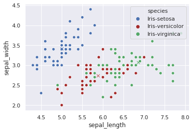

```python
c = {'Iris-setosa': 'b', 'Iris-versicolor': 'brown', 'Iris-virginica': 'g'}
seaborn.scatterplot(x='sepal_length', y='sepal_width', data=data_complete,
                    hue='species', palette=c)
matplotlib.pyplot.plot('sepal_length', 'sepal_width', 'gx', data=centers[0])
matplotlib.pyplot.plot('sepal_length', 'sepal_width', 'bx', data=centers[1])
matplotlib.pyplot.plot('sepal_length', 'sepal_width', 'rx', data=centers[2])
```